# Relative Value Optimization Project

Derek Stockman

2023-07-18

Welcome! With this project, I hope to provide a clear demonstration of my capabilities. I’ll utilize both Python and R programming languages. While my experience is primarily with R, I am actively improving my python skills. While I don’t claim to be an expert in linear programming nor a developer, I do posess the curiosity and intelligence to deliver decision-useful projects and analysis.

**THIS PROJECT IS NOT YET COMPLETE!**

At this time, I am reviewing the output of the optimizations and have noticed some inconsistencies regarding the returns calculated by the Black-Litterman model. The current obstacle is in familiarizing myself with some augmentation to the matrix algebra that the authors of the PortfolioAnalytics package made to the original Black-Litterman formula. When spot-checking the output by hand with the original formula, I arrive at slightly different results, so this issue has slowed progress.

Further, there are some computing limitations. I am running this on my laptop and simply don’t have the processing power to perform some of the larger optimizations later on in the project. There also seems to be an issue with my system assuming that large matrices are invertible due to the determinant being near zero but not actually zero. **These constraints have forced me to shrink the number of assets to the first 60 in the index.**

With all that said, let’s continue.

#### Outline

The main idea of this project is to provide a methodology for an active manager to identify relative value opportunities along the curve and then construct an optimal portfolio based on those opportunites. It was was inspired by my work with factor modeling in corporate bond markets. My research uncovered the persistence of a Value factor in determining excess returns, particularly within the Investment Grade universe. Measurement of Value must account for the term structure of interest rates and spread. It is preferable to perform this analysis upon the Option Adjusted Spread (OAS) of individual bonds, unfortunately I was unable to locate publicly available OAS data, so we will settle for using the Yield-to-Worst (YTW) statistic.

We begin by fitting a curve using the Nelson-Siegel model to the YTW of the bonds included in each sector. From there, we calculate the implied spread to the curve is for each bond. This value represents the potential spread compression possible if the bond were to fully converge with peers. The potential spread compression is multiplied by each bond’s duration to arrive at an implied performance. This value will serve as a critical input to the subsequent optimization.

The Black-Litterman model offers a intuitive method for combining an analyst’s view with the equilibrium return of an asset. With YTW serving as the equilibrium returns and the implied performance calculated by the previously described relative valuation methodology, we can produce a more intuitive portfolio for capturing the excess return driven by the Value factor.

#### Set up / Importation / Pre-processing

```r
library(reticulate)
use_python("c:/Users/dstoc/Documents/Python Scripts/First Project/.venv/Scripts/python.exe")
```

We utilize BlackRock iShares Aaa-A Rated Corporate Bond ETF (QLTA) for CUSIP-level details and analytics.

```python
import pandas as pd
df = pd.read_excel('C:/Users/dstoc/Documents/Python Scripts/First Project/QLTA.xlsx')
```

|  | Name | Sector | Asset Class | CUSIP | Market Value | Weight (%) | Notional Value | Par Value | Location | Exchange | Currency | Duration | YTM (%) | FX Rate | Maturity | Coupon (%) | Mod. Duration | Yield to Call (%) | Yield to Worst (%) | Real Duration | Real YTM (%) | Market Currency | Accrual Date | Effective Date |
| --- | --- | --- | --- | --- | --- | --- | --- | --- | --- | --- | --- | --- | --- | --- | --- | --- | --- | --- | --- | --- | --- | --- | --- | --- |
| 1 | ANHEUSER-BUSCH COMPANIES LLC | Consumer Non-Cyclical | Fixed Income | ['03522AAJ9'] | 3972588.66 | 0.45249 | 3972588.66 | 4105000 | Belgium | -- | USD | 13.02 | 5.27 | 1 | Feb 01, 2046 | 4.9 | 13.1 | -- | 5.27 | 13.1 | 5.27 | USD | Feb 01, 2019 | May 13, 2019 |
| 2 | PFIZER INVESTMENT ENTERPRISES PTE | Consumer Non-Cyclical | Fixed Income | ['716973AG7'] | 1867674.61 | 0.21273 | 1867674.61 | 1805000 | United States | -- | USD | 15.16 | 5.09 | 1 | May 19, 2053 | 5.3 | 15.13 | -- | 5.09 | 15.02 | 5.09 | USD | May 19, 2023 | May 19, 2023 |
| 3 | PFIZER INVESTMENT ENTERPRISES PTE | Consumer Non-Cyclical | Fixed Income | ['716973AE2'] | 1636331.22 | 0.18638 | 1636331.22 | 1625000 | United States | -- | USD | 7.83 | 4.69 | 1 | May 19, 2033 | 4.75 | 7.85 | -- | 4.69 | 7.69 | 4.69 | USD | May 19, 2023 | May 19, 2023 |
| 4 | MICROSOFT CORPORATION | Technology | Fixed Income | ['594918CE2'] | 1448999.23 | 0.16505 | 1448999.23 | 1944000 | United States | -- | USD | 17.4 | 4.56 | 1 | Mar 17, 2052 | 2.92 | 17.41 | -- | 4.56 | 17.41 | 4.56 | USD | Mar 17, 2021 | Mar 17, 2021 |
| 5 | VISA INC | Technology | Fixed Income | ['92826CAD4'] | 1367019.04 | 0.15571 | 1367019.04 | 1396000 | United States | -- | USD | 2.28 | 4.67 | 1 | Dec 14, 2025 | 3.15 | 2.35 | -- | 4.67 | 2.35 | 4.67 | USD | Dec 14, 2015 | Dec 14, 2015 |
| 6 | WELLS FARGO &amp; COMPANY MTN | Banking | Fixed Income | ['95000U2M4'] | 1351960.38 | 0.15399 | 1351960.38 | 1462000 | United States | -- | USD | 12.42 | 5.69 | 1 | Apr 04, 2051 | 5.01 | 14.02 | -- | 5.62 | 13.97 | 5.62 | USD | Mar 30, 2020 | Mar 30, 2020 |
| 7 | WELLS FARGO &amp; COMPANY MTN | Banking | Fixed Income | ['95000U3B7'] | 1299970.27 | 0.14807 | 1299970.27 | 1325000 | United States | -- | USD | 6.97 | 5.48 | 1 | Jul 25, 2033 | 4.9 | 7.11 | -- | 5.41 | 7.11 | 5.41 | USD | Jul 25, 2022 | Jul 25, 2022 |
| 8 | MICROSOFT CORPORATION | Technology | Fixed Income | ['594918CC6'] | 1260102.82 | 0.14353 | 1260102.82 | 1839000 | United States | -- | USD | 17.47 | 4.57 | 1 | Jun 01, 2050 | 2.52 | 17.53 | -- | 4.57 | 17.53 | 4.57 | USD | Jun 01, 2020 | Jun 01, 2020 |
| 9 | CITIGROUP INC | Banking | Fixed Income | ['172967MP3'] | 1254766.27 | 0.14292 | 1254766.27 | 1324000 | United States | -- | USD | 5.56 | 5.86 | 1 | Mar 31, 2031 | 4.41 | 5.72 | -- | 5.48 | 5.72 | 5.48 | USD | Mar 31, 2020 | Mar 31, 2020 |
| 10 | APPLE INC | Technology | Fixed Income | ['037833BX7'] | 1203863.8 | 0.13712 | 1203863.8 | 1197000 | United States | -- | USD | 13.58 | 4.7 | 1 | Feb 23, 2046 | 4.65 | 13.72 | -- | 4.7 | 13.72 | 4.7 | USD | Feb 23, 2016 | Feb 23, 2016 |

[output cut: 2730 more lines]

#### Analysis

First, convert each bond’s maturity to a numeric value for calculation purposes.

```python
import pandas as pd
from datetime import datetime, timedelta

# Define the date format
date_format = "%b %d, %Y"

# Define a function to convert a date string to the number of days away
def convert_to_years(date_str):
    date_obj = datetime.strptime(date_str, date_format)
    current_date = datetime.now()
    years_away = (date_obj - current_date).days / 365

    if years_away < 0:
        years_away = years_away + 100  # Add 100 years (365.25 days per year on average)

    return years_away

# Apply the function to the 'Date' column
df2['MaturityYears'] = df2['Maturity'].apply(convert_to_years)
```

Define a function that fits a Nelson-Siegel curve to the Yield-to-Worst values of individual bonds in each sector.

```python
import numpy as np
from nelson_siegel_svensson.calibrate import calibrate_ns_ols, errorfn_ns_ols
from matplotlib import pyplot as plt

def my_NS_func(x_df):
    time = np.array(x_df["MaturityYears"])
    yld = np.array(x_df["Yield to Worst (%)"])

    #plt.plot(time,yld, "r+");
    curve, status = calibrate_ns_ols(
        time,yld, tau0=1.0
    )  # starting value of 1.0 for the optimization of tau
    assert status.success
    curve

    Yhat = x_df['Yield to Worst (%)'].apply(curve)
    x_df.loc[:,'Yhat'] = Yhat

    Spread_to_Curve = x_df['Yield to Worst (%)'] - x_df['Yhat']
    return Spread_to_Curve
```

```python
df3 = df2
df3['Spread to Curve'] = df3.groupby('Sector').apply(my_NS_func).reset_index(level=0, drop=True)
```

Below is an example of what happens within the function above, applied to just one sector.

```
## NelsonSiegelCurve(beta0=5.508202719740116, beta1=1.2705638188194448, beta2=-4.658592057454102, tau=1.46031091126041)
```

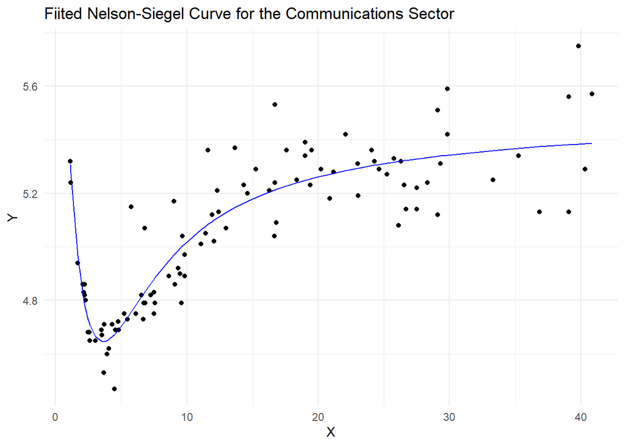

Calculate additional performance driven by compression of bond’s yield to the curve % Change in Price = Duration x Spread to Curve

```python
df3.loc[:,'Implied Performance'] = (df3['Duration'] * df3['Spread to Curve']) + df3['Yield to Worst (%)']
df_final = df3
```

#### Results

|  | Name | Sector | Weight (%) | Notional Value | CUSIP | Duration | YTM (%) | Maturity | Coupon (%) | Mod. Duration | Yield to Worst (%) | MaturityYears | Spread to Curve | Implied Performance |
| --- | --- | --- | --- | --- | --- | --- | --- | --- | --- | --- | --- | --- | --- | --- |
| 1 | ANHEUSER-BUSCH COMPANIES LLC | Consumer Non-Cyclical | 0.45249 | 3972588.66 | ['03522AAJ9'] | 13.02 | 5.27 | Feb 01, 2046 | 4.9 | 13.1 | 5.27 | 22.5561643835616 | 0.763806662930683 | 15.2147627513575 |
| 2 | PFIZER INVESTMENT ENTERPRISES PTE | Consumer Non-Cyclical | 0.21273 | 1867674.61 | ['716973AG7'] | 15.16 | 5.09 | May 19, 2053 | 5.3 | 15.13 | 5.09 | 29.8547945205479 | 0.592608536399605 | 14.073945411818 |
| 3 | PFIZER INVESTMENT ENTERPRISES PTE | Consumer Non-Cyclical | 0.18638 | 1636331.22 | ['716973AE2'] | 7.83 | 4.69 | May 19, 2033 | 4.75 | 7.85 | 4.69 | 9.84109589041096 | 0.209332279639575 | 6.32907174957788 |
| 4 | MICROSOFT CORPORATION | Technology | 0.16505 | 1448999.23 | ['594918CE2'] | 17.4 | 4.56 | Mar 17, 2052 | 2.92 | 17.41 | 4.56 | 28.6821917808219 | 0.0706035983772821 | 5.78850261176471 |
| 5 | VISA INC | Technology | 0.15571 | 1367019.04 | ['92826CAD4'] | 2.28 | 4.67 | Dec 14, 2025 | 3.15 | 2.35 | 4.67 | 2.40821917808219 | 0.180552570410368 | 5.08165986053564 |
| 6 | WELLS FARGO &amp; COMPANY MTN | Banking | 0.15399 | 1351960.38 | ['95000U2M4'] | 12.42 | 5.69 | Apr 04, 2051 | 5.01 | 14.02 | 5.62 | 27.7287671232877 | 0.258319710523633 | 8.82833080470352 |
| 7 | WELLS FARGO &amp; COMPANY MTN | Banking | 0.14807 | 1299970.27 | ['95000U3B7'] | 6.97 | 5.48 | Jul 25, 2033 | 4.9 | 7.11 | 5.41 | 10.0246575342466 | 0.0475184745366928 | 5.74120376752075 |
| 8 | MICROSOFT CORPORATION | Technology | 0.14353 | 1260102.82 | ['594918CC6'] | 17.47 | 4.57 | Jun 01, 2050 | 2.52 | 17.53 | 4.57 | 26.8876712328767 | 0.0806216132586455 | 5.97845958362854 |
| 9 | CITIGROUP INC | Banking | 0.14292 | 1254766.27 | ['172967MP3'] | 5.56 | 5.86 | Mar 31, 2031 | 4.41 | 5.72 | 5.48 | 7.7041095890411 | 0.117871662359523 | 6.13536644271895 |
| 10 | APPLE INC | Technology | 0.13712 | 1203863.8 | ['037833BX7'] | 13.58 | 4.7 | Feb 23, 2046 | 4.65 | 13.72 | 4.7 | 22.6164383561644 | 0.210446533112224 | 7.557863919664 |

[output cut: 2730 more lines]

#### Optimization via the Black-Litterman Model

The Black-Litterman model offers a framework for analysts to update equilibrium returns with their views on specific assets. The model operates like a weighted average between the implied returns and views, with each being scaled by the covariance matrix and the analyst’s confidence in each view respectively.

For the purposes of this example, returns were generated in place of observed returns. However, each sector received a unique drift term in an attempt to replicate some level of realistic correlation.

Further, the confidence level of each view is the most difficult parameter to estimate.We will operate under the very optimistic assumption that we have 100% confidence in our views, or rather, there is no variance in our confidence. This is represented by setting the diagonal elements of the Omega matrix equal to Zero. Essentially, the higher the variance in each asset, the less confident we are in the view provided by the Nelson-Siegel model.

```r
# Create a dataframe populated with the YTW values of each bond.
#NS_output <- subset(NS_output, Sector == 'Basic Industry')
NS_output <-NS_output[1:60,]
R <- t(NS_output$`Yield to Worst (%)`)
funds <- NS_output$CUSIP
colnames(R)<- funds
for(i in 1:89){
  R = rbind(R,t(NS_output$`Yield to Worst (%)`))
}

# Generate drift terms for each sector
sector_drifts <- rnorm(length(unique(NS_output$Sector)),0,1)/100

# iterate over each observation for each bond, simulating a random walk with sector-based drift
for(i in 90:1){
  for(k in 1:ncol(R)){
    drift <- sector_drifts[match(NS_output[match(colnames(R)[k],NS_output$CUSIP),"Sector"],
                   unique(NS_output$Sector))]
    if(i==90){
    R[i,k] <- R[i,k]
    }else{
      R[i,k] <- R[i,k] * (1 + rnorm(1,drift,1)/100)
    }
    }
}
dates <- seq.Date(Sys.Date() - nrow(R)+1 ,Sys.Date(), by = 1)
R <- as.xts(R, order.by = dates)
```

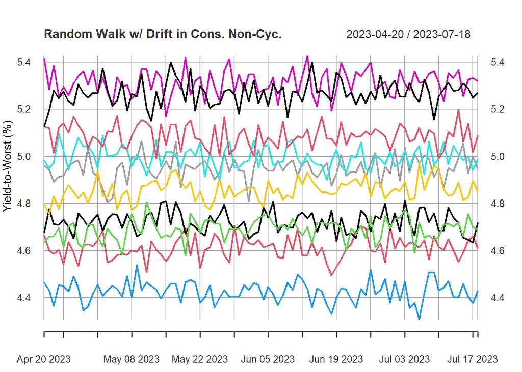

We now specify the components of the Black-Litterman Model

```r
Mu <- as.vector(t(NS_output$`Yield to Worst (%)`))
Sigma <- cov(R)
Views <- NS_output$`Implied Performance`
Picking <- matrix(0, nrow = length(Views), ncol = length(Views))
for(i in 1:nrow(Picking)){
  Picking[i,i] <- 1 # 1 for absolute views
}

Omega <- matrix(0, nrow = length(Views), ncol = length(Views))
diag(Omega) <- 0 #runif(length(Views),0,.3) #1
```

Note that the leverage constraint allows for some leeway when utilizing other optimizers,

```r
#### First Portfolio ####
bl1.portf <- portfolio.spec(assets=funds)
bl1.portf <- add.constraint(portfolio=bl1.portf, type="full_investment")
bl1.portf <- add.constraint(portfolio=bl1.portf, type="leverage", min_sum=0.99, max_sum=1.01)
bl1.portf <- add.constraint(portfolio=bl1.portf, type="long_only",min_mult =NULL, max_mult=NULL)
bl1.portf <- add.constraint(portfolio = bl1.portf, type = "box",
                            min= min(NS_output$`Weight (%)`)/100,max = .1,min_mult =NULL, max_mult=NULL )
bl1.portf <- add.objective(portfolio=bl1.portf, type="return", name="mean")
bl1.portf
```

```
## PortfolioAnalytics Portfolio Specification
##
## Call:
## portfolio.spec(assets = funds)
##
## Number of assets: 60
## Asset Names
## NULL
## More than 10 assets, only printing the first 10
##
## Constraints
## Enabled constraint types
##      - full_investment
##      - leverage
##      - long_only
##      - box
##
## Objectives:
## Enabled objective names
##      - mean
```

```r
bl1_opt <- optimize.portfolio(R=R, portfolio=bl1.portf,
                              optimize_method="ROI", trace=TRUE,
                              momentFUN = "portfolio.moments.bl.corrected",
                              P = Picking,
                              Mu = Mu,
                              Sigma = Sigma,
                              Views = Views,
                              Omega = Omega
                              )
print(bl1_opt$objective_measures)
```

```
## $mean
##    mean
## 15.4684
```

```r
#### Second Portfolio ####
bl2.portf <- bl1.portf
sector_groups <- list()
group_mins <- list()
group_maxs <- list()
for (i in 1:length(unique(NS_output$Sector))){
  s <- subset(NS_output, Sector == unique(NS_output$Sector)[i])
  for (j in 1:nrow(s)) {
    cusip <- s$CUSIP[j]
    pos <- match(cusip, colnames(R))
    sector_groups[[unique(NS_output$Sector)[i]]][j] <- pos
  }
  group_mins[[i]] <- pmax(sum(s$`Weight (%)`) - 10,0)/100
  group_maxs[[i]] <- pmax(sum(s$`Weight (%)`) + 10,0)/100
}


bl2.portf <- add.constraint(portfolio=bl2.portf, type="group",
                            groups = sector_groups,
                            group_min = unlist(group_mins),
                            group_max = unlist(group_maxs)+.2
                            )
bl2_opt <- optimize.portfolio(R=R, portfolio=bl2.portf,
                              optimize_method="ROI",
                              trace=TRUE,
                              momentFUN = "portfolio.moments.bl.corrected",
                              P = Picking,
                              Mu = Mu,
                              Sigma = Sigma,
                              Views = Views,
                              Omega = Omega
                              )
print(bl2_opt$objective_measures)
```

```
## $mean
##     mean
## 13.80899
```

Let’s explore our results! It appears that there is potential value within the Communications Sector. While this quantitative approach is not all-inclusive, the identification of opportunities within these sectors allows credit analysts to better prioritize their research efforts. Potentially allowing the team to capture even more alpha.

```
##                  Sector Initial_Weight New_Weight
## 1 Consumer Non-Cyclical     0.38900453  0.3298079
## 2            Technology     0.18456636  0.1103320
## 3               Banking     0.27312104  0.0646941
## 4     Consumer Cyclical     0.04593213  0.1020664
## 5        Communications     0.07759236  0.3020664
## 6                Energy     0.02978359  0.1010332
```

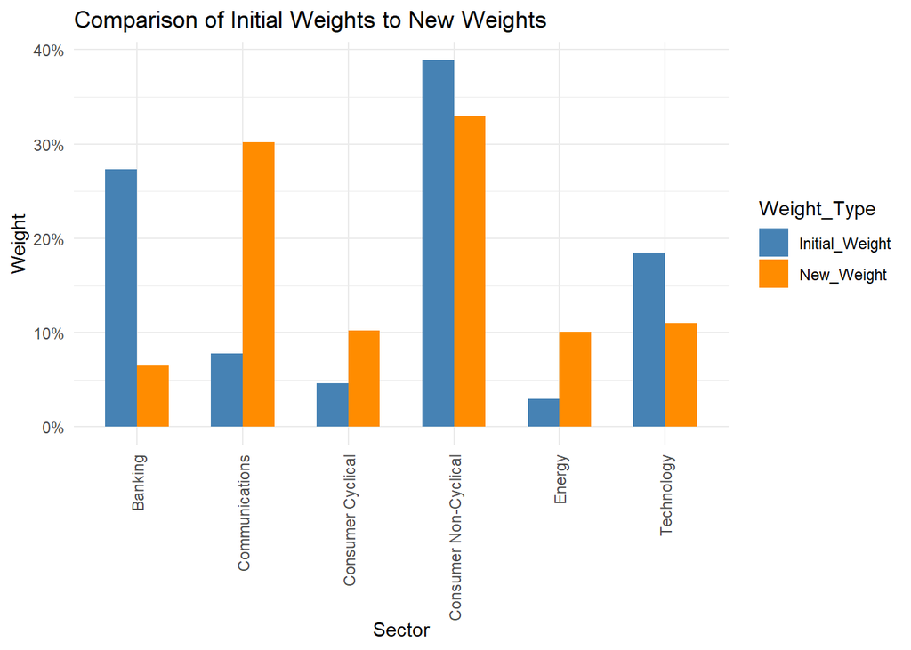

Next, I intend to add a duration target to stay within a reasonable range from the index’s initial value. This should offer an even more practical solution. However, the use of a custom objective function requires the use of an alternative solver (Differential Evolution) that is currently throwing an error. Hoping to resolve it soon.

Other improvements include minimization of another risk factor, such as probability of default.

```r
#### Third Portfolio ####
# Add duration target
# NS_output$New_Weight <- NS_output$`Weight (%)` / sum(NS_output$`Weight (%)`)
#
# dur_target <- round(sum(NS_output$Duration * NS_output$New_Weight),2)
#
# absolute_duration_deviation <- function(R, weights,holdings,init_port_dur){
#
#           durations <- holdings$Duration[1:ncol(R)]
#           init_weights <- holdings$New_Weight[1:ncol(R)]
#           weighted_dur <- sum(weights * durations)
#           dur_diff <- abs(weighted_dur - init_port_dur)
#           return(dur_diff)
# }
#
#
# bl3.portf <- bl2.portf
#
# bl3.portf <- add.objective(portfolio=bl3.portf, type="risk",
#                            name="absolute_duration_deviation",
#                            arguments=list(holdings = NS_output, init_port_dur = dur_target))
# library(DEoptim)
# library(foreach)
# bl3_opt <- optimize.portfolio(R=R, portfolio=bl3.portf,
#                               optimize_method="DEoptim",
#                               search_size = 20000,
#                               itermax = 50,
#                               trace = TRUE,
#                               traceDE = 5,
#                               parallel = TRUE,
#                               #max_permutations = 50000,
#                               momentFUN = "portfolio.moments.bl.corrected",
#                               P = Picking,
#                               Mu = Mu,
#                               Sigma = Sigma,
#                               Views = Views,
#                               Omega = Omega
# )
#
# print(bl3_opt$objective_measures)
#
#
```

## References

- Black-Litterman
  - https://people.duke.edu/~charvey/Teaching/BA453_2006/Idzorek_onBL.pdf
  - https://github.com/braverock/PortfolioAnalytics
  - https://papers.ssrn.com/sol3/papers.cfm?abstract_id=1314585
- Nelson-Siegel
  - https://www.jstor.org/stable/2352957
  - https://github.com/luphord/nelson_siegel_svensson
  - https://papers.ssrn.com/sol3/papers.cfm?abstract_id=1314585
- BlackRock
  - https://www.ishares.com/us/products/239431/ishares-aaa-a-rated-corporate-bond-etf